# Session 1 - Introduction.Rmd

# Advantages of R for data analysis

1. *Cutting edge* analyses. In psychology R is the standard package to run *mixed effects models*. It also interfaces with *Stan* (Bayesian Analysis), via a package called *brms*
2. *Variety* of statistical methods. It’s huge and much larger than commercial packages, e.g. SPSS
3. *Transparency* of code. The code resembles the underlying mathematical model.
4. Statistical models are *stored in memory* and are open to exploration/interrogation. For example, it is easy to inspect the residuals of our model.

# Correlations

## Simple pairwise correlation

Main function for a pairwise correlation is `cor.test`. Have a look at the example. Note that we have used the `apa` library to turn this into a nice output.

```r
df = read_csv("WHR_2017.csv")
```

```r
cor_apa(cor)
```

```
r(153) = .81, p < .001
```

Often, you will need to report your results “in-line” (i.e. in the body of your text). To do this in R you use backticks. There are 3 backticks for a block, but only 1 for in-line code (and no curly brackets).

## EXERCISE - EXPLORING CORRELATIONS

Explore other correlations in the data!!

## Multiple pairwise comparisons

This is a bit more tricky. The best approach is to create a dataframe containing only those variables that you wish to conduct the pairwise correlations on. The `cor` function from base R creates a correlation matrix. But results are not very publication-ready. They can be tidied up via the `kable` package (in `knitr`). There is also the fantastic `corrplot` which will give you a great graphical representation.

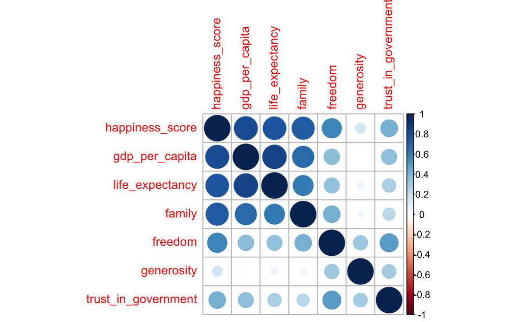

# Running a model

## Basic syntax of a regression model

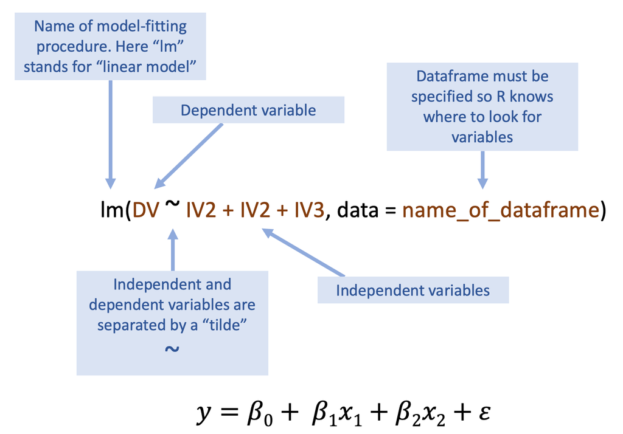

R regression syntax

```r
df = read_csv("WHR_2017.csv")

mod_hs_gdp <- lm(happiness_score ~ gdp_per_capita, data = df)

# "mod" = model.
# "hs_gdp" = hs is predicted by gdp

mod_hs_gdp # This shows you the key statistics, but it's not very informative

summary(mod_hs_gdp) # This is much more informative but it's not pretty to look at

tidy(summary(mod_hs_gdp)) # `tidy` from the `broom` package makes it into a very nice table

# or to make this a bit more "publication-ready"

knitr::kable(tidy(summary(mod_hs_gdp)))
```

[output not shown]

```r
report_coef = function(mod){
  sm = summary(mod)
  results_vector = rep("", length(mod$coefficients))
  for (i in 1:length(mod$coefficients)){
    results_vector[i] = paste0("β = ", round(sm$coefficients[i, 1], 2), ", t = ", round(sm$coefficients[i, 3], 2), ", p = ", sprintf("%.3f", round(sm$coefficients[i, 4], 3)))
  }
  return(results_vector)
}
```

NB the code to create the function is tricky. It took me 20 minutes to write with a lot of googling. A newbie would spend much longer. However, if you are writing a thesis which involves the in-line reporting of the results of a large number of linear models, this could save you a lot of time in the long run.

## Model diagnostics

But is it a good model for the data. Let’s do a plot to find out.

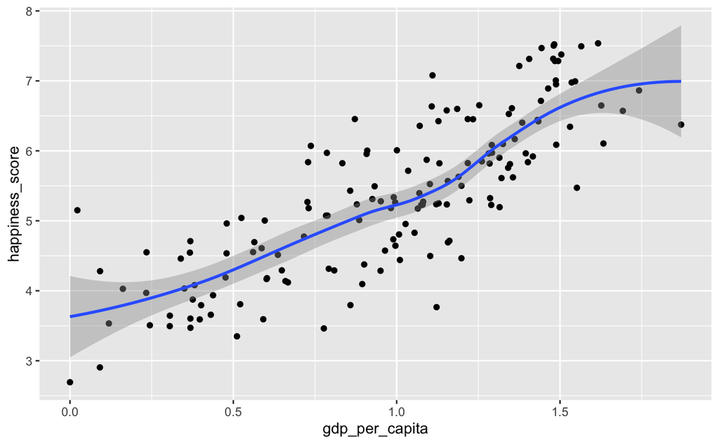

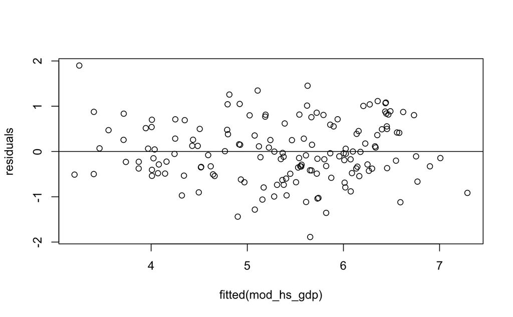

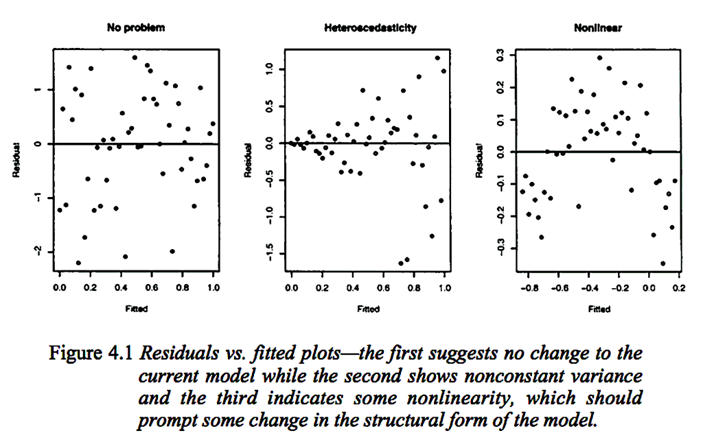